# Data visualization

#### 3: Map a continuous variable to color, size, and shape. How do these aesthetics behave differently for categorical vs. continuous variables?

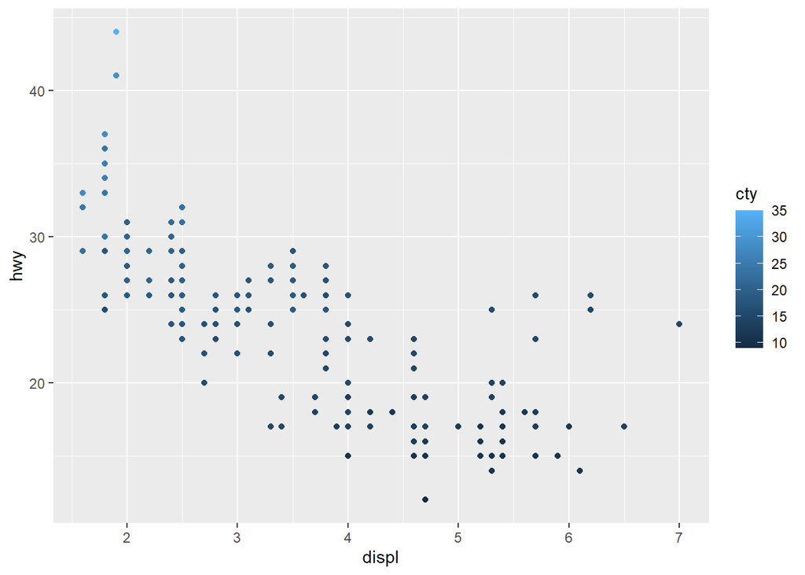

```r
ggplot(data = mpg) +
  geom_point(mapping = aes(x = displ, y = hwy, color = cty ))
```

For color it creates a continuous shade, for shape it shows error as a continuous variable cannot be usd as there are only specifically 6 shapes that can be used at a time.

For size it probably discretizes the continuous value but floor or ceiling function and assigs accordingly.

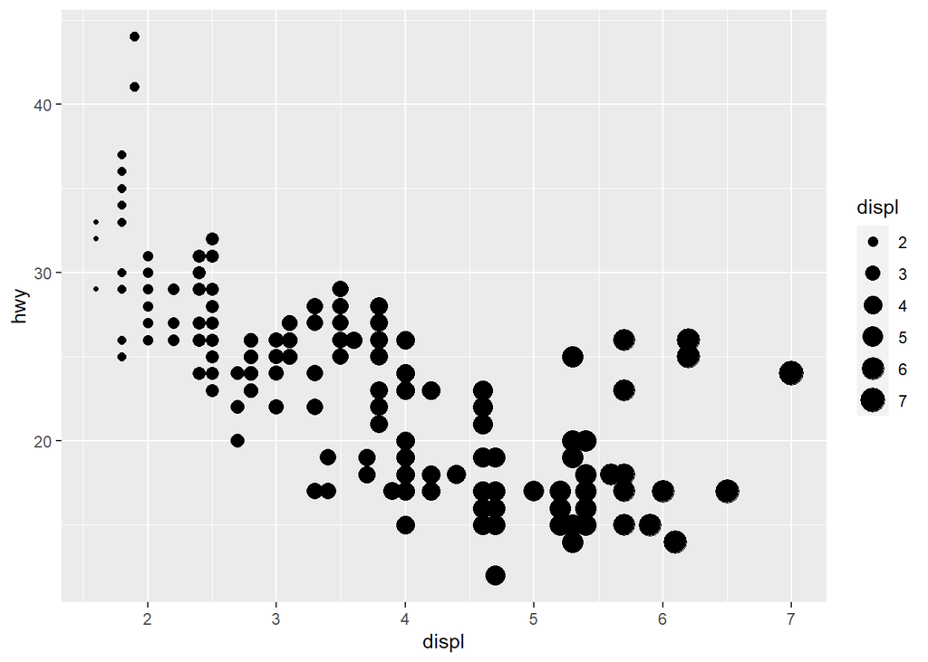

```r
ggplot(data = mpg) +
  geom_point(mapping = aes(x = displ, y = hwy, size = displ ))
```

#### 4: What happens if you map the same variable to multiple aesthetics?

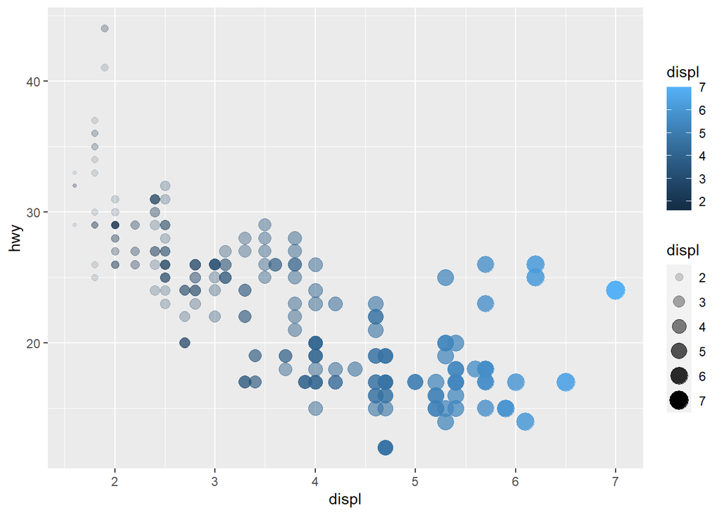

```r
ggplot(data = mpg) +
  geom_point(mapping = aes(x = displ, y = hwy, size = displ, color= displ, alpha= displ))
```

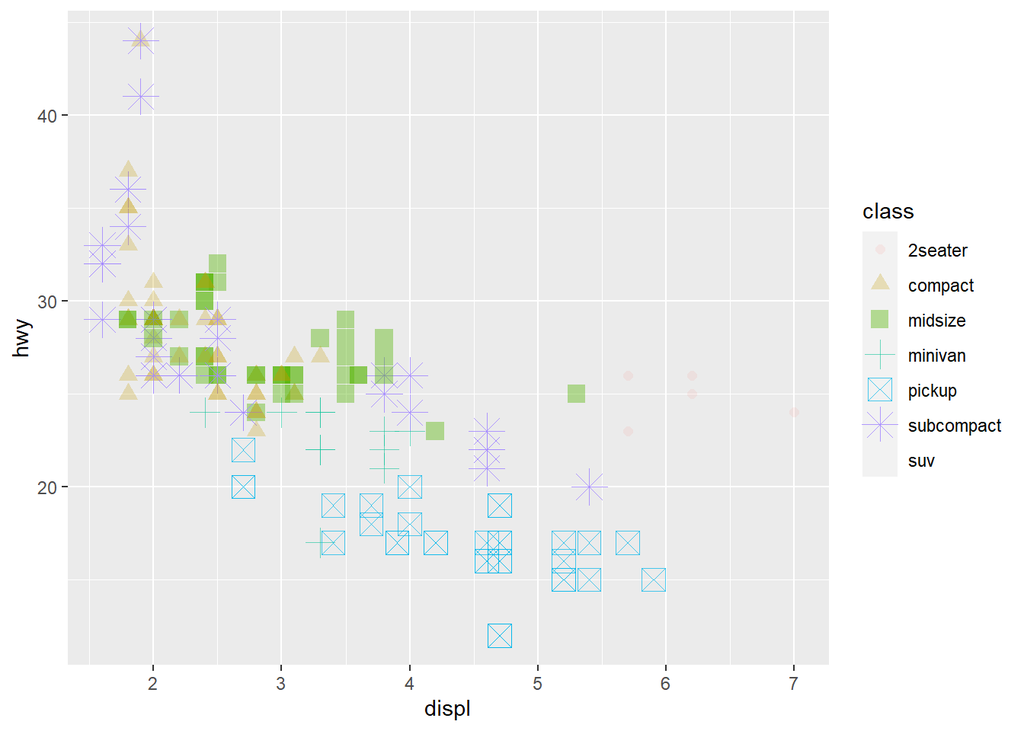

```r
ggplot(data = mpg) +
  geom_point(mapping = aes(x = displ, y = hwy, size = class, color= class, alpha= class, shape=class))
```

#### 5: What does the stroke aesthetic do? What shapes does it work with?

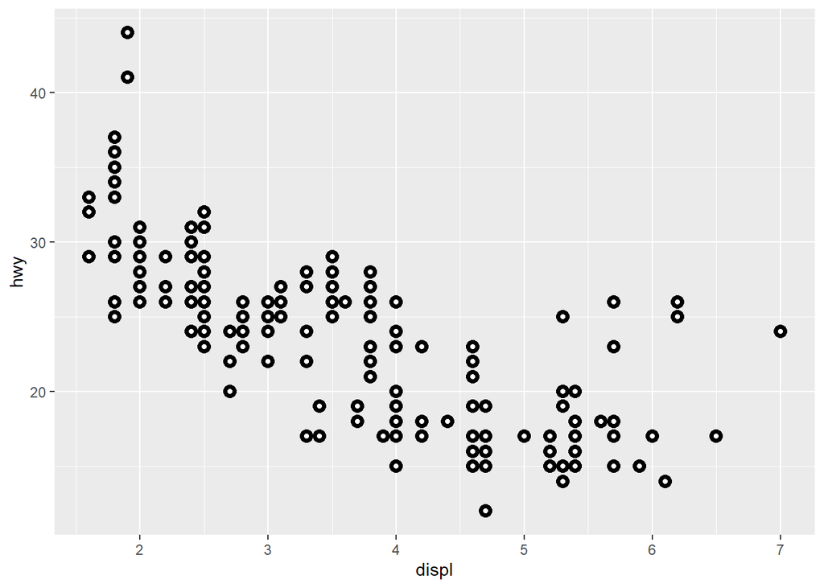

```r
ggplot(mpg, mapping = aes(x = displ, y = hwy)) +
  geom_point(shape = 21, colour = "black", fill = "white", stroke = 2)
```

As we can see above the stokes gives the size of the border for the points, for which we use a particular shape, we can fill teh shape with “fill”, increase the size using “size”, chose colour using “color” and finally change the border using “stokes”.

It works with shape from 15 to 24.

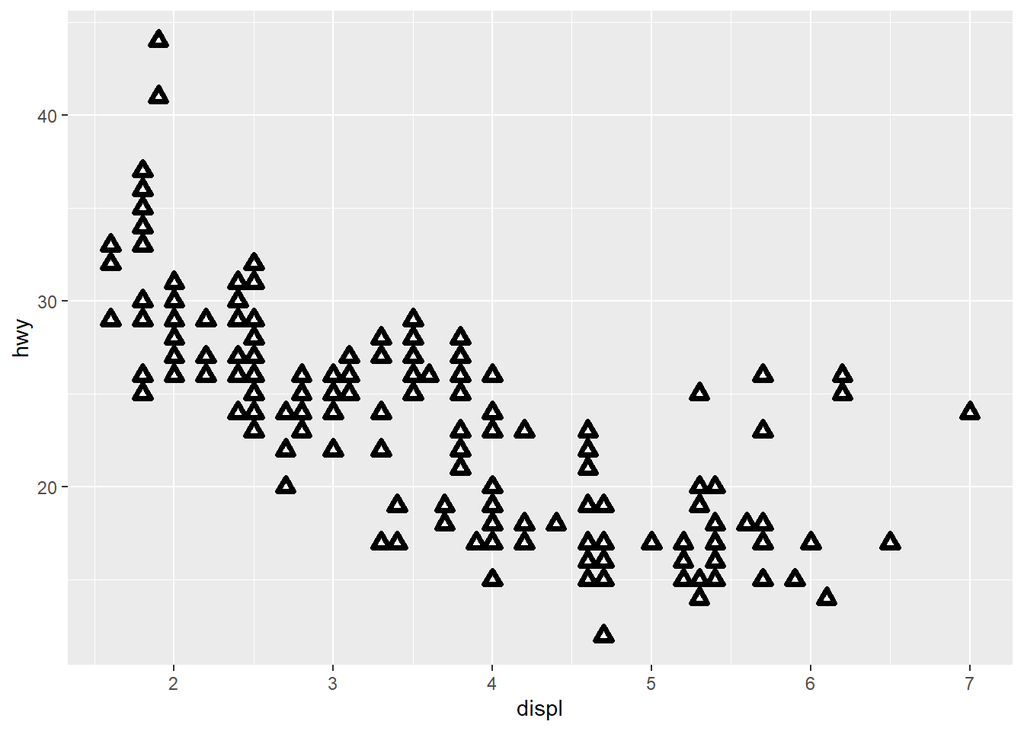

```r
ggplot(data=mpg, mapping = aes(x = displ, y = hwy)) +
  geom_point(shape = 24, colour = "black", fill = "white", stroke = 2)
```

#### 6: What happens if you map an aesthetic to something other than a variable name, like aes(colour = displ < 5)? Note, you’ll also need to specify x and y.

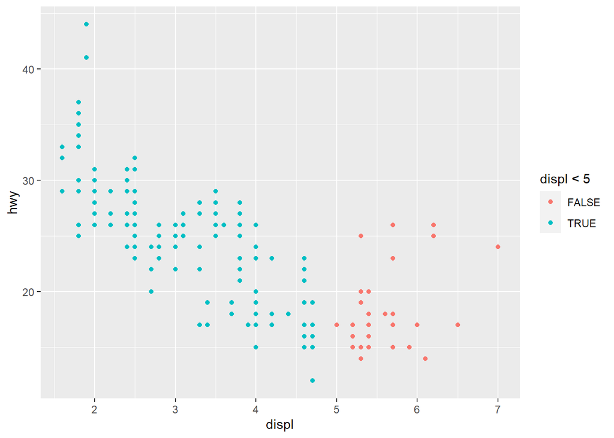

```r
ggplot(data=mpg)+
  geom_point(mapping = aes(x = displ, y = hwy, colour = displ<5))
```

As we see, this creates a binary response in case of colors. two colours are created according to the color palattee and at the same time, the legend shows a binary bifurcation depending on the size od display (this is because we gave 5, and display values are near to 5 )